# The life bar

In the next two parts, we will design and code the life and energy bars to put them in the party’s Heads-Up Display (HUD) in the next lesson.

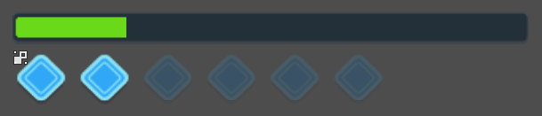

These bars give the player feedback on each battler’s state, but we can also use them to provide real-time feedback on the action they can use. We will code the energy bar so that when you hover an action in the UIActionMenu, you get a preview of the energy cost in the Head-Up Display.

[figure not shown]

We will see this in the next lesson, where we will introduce a global signal bus, a pattern we use to loosely connect distant nodes in Godot, limiting coupling.

For now, let’s focus on the life bar. It will rely on the built-in *TextureProgress* node, while the energy bar will show you how to create a custom discrete counter.

## The life bar

Godot comes with two nodes to create progress bars: *ProgressBar* and *TextureProgress*. The first relies on the theme system and is ideal for loading bars in plugins, for example, while you’ll most likely use the second for in-game gauges.

Create a new scene with a *TextureProgress* node as its root and name it *UILifeBar*. Add both a *Tween* and an *AnimationPlayer* node as its children.

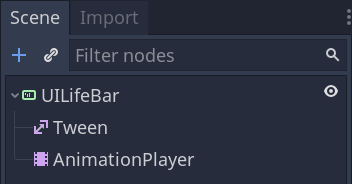

Let’s configure the *UILifeBar* node. Select it and set its *Textures -> Under* and *Textures -> Progress* to `life_bar_bg.png` and `life_bar_fill.png`, or any base and fill texture you’d like to use.

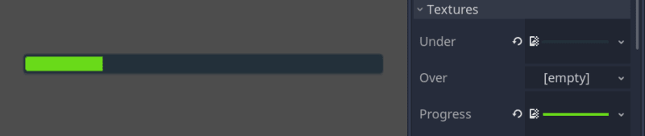

The *Under* and *Over* textures are always visible and sandwich the *Progress* one. The node will clip the *Progress* texture based on the *Min Value*, *Max Value*, and *Value* properties. We will control those via code.

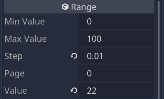

Set the *Step* property to `0.01` so we can smoothly animate the bar. Godot will round the bar’s internal value based on the *Step* property, which can help to create some kinds of discrete bar designs.

### The bar’s animations

I designed two animations with the *AnimationPlayer*: “danger”, which plays when the battler’s health is low, and “damage”, which we’ll play when the battler takes damage.

The danger animation affects the *UILifeBar*’s *Tint -> Progress* property, which works like *Modulate* but only affects the *Textures -> Progress* texture.

It’s a 1.6 seconds looping animation with three keys that keep the bar green and one that tints the bar in red.

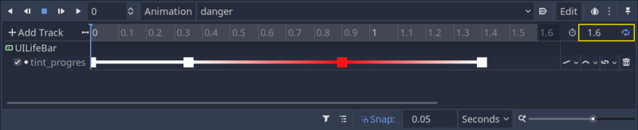

The damage animation is much shorter, with a duration of 0.2 seconds. It flashes the entire node using the *Modulate* property.

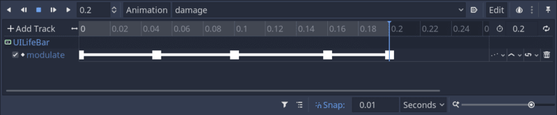

While the keys appear all white, some use the color picker’s *Raw* color mode to use tones that brighten the pixels. On those keys, I’m using a value of `4` in the RGB color channels.

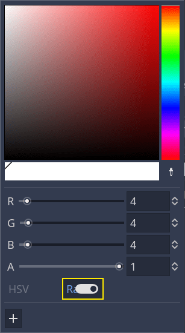

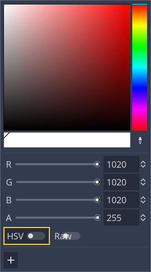

And with that, we can move on to the code.

## The life bar’s code

Attach a new script to the *UILifeBar* node.

```
# Animated life bar.
extends TextureProgress

# Rate of the animation relative to `max_value`. A value of 1.0 means the animation fills the entire
# bar in one second.
export var fill_rate := 1.0

# When this value changes, the bar smoothly animates towards it using a tween.
# See the setter function below for the details.
var target_value := 0.0 setget set_target_value

onready var _tween: Tween = $Tween
onready var _anim_player: AnimationPlayer = $AnimationPlayer


# We initialize the bar through a function because we need to set the `target_value` without
# passing through its setter function.
func setup(health: float, max_health: float) -> void:
    max_value = max_health
    value = health
    target_value = health
    # We animate the bar using the `Tween` node. When the tween completes, we may need to play the
    # "danger" animation.
    _tween.connect("tween_completed", self, "_on_Tween_tween_completed")


func set_target_value(amount: float) -> void:
    # If the `amount` is lower than the current `target_value`, it means the battler lost health.
    if target_value > amount:
        _anim_player.play("damage")

    target_value = amount
    if _tween.is_active():
        _tween.stop_all()

    # We have to calculate the animation's duration every time as we want to have a constant rate or
    # speed at which the bar fills or empties itself.
    var duration := abs(target_value - value) / max_value * fill_rate
    # We then tween from the current `value` to the `target_value` for `duration` seconds.
    _tween.interpolate_property(self, "value", value, target_value, duration, Tween.TRANS_QUAD)
    _tween.start()


# When the tween animation completes, we play the "danger" animation if the battler's health is down
# to 20%.
func _on_Tween_tween_completed(object: Object, key: NodePath) -> void:
    if value < 0.2 * max_value:
        _anim_player.play("danger")
```

And with that, your life bar can animate smoothly and even flash when the player loses health. We will use it in the Heads-Up Display (HUD) lesson, right after coding the energy bar.